# Homework_4

#### c.To make things easier to read, put par(las=2) before your plot to make the text perpendicular to the axis. Make a barplot of major_count. Make sure to label the title with something informative (check the vignette if you need), label the x and y axis, and make it any color other than grey. Assign the major_category labels to their respective bar. Flip the barplot horizontally so that bars extend to the right, not upward. All of these options can be done in a single pass of barplot(). Note: It’s okay if it’s wider than the preview pane.

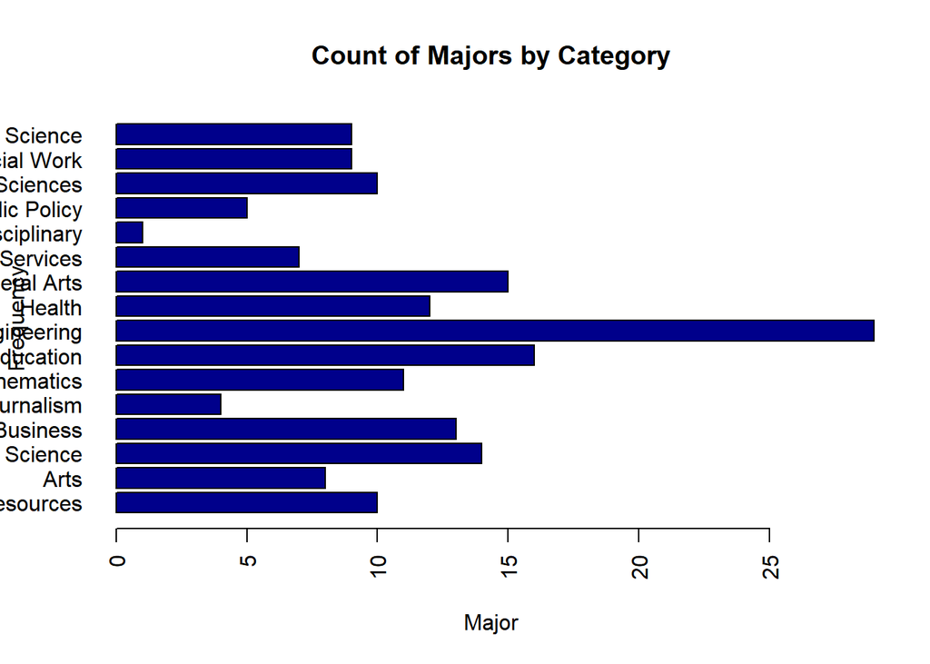

```r
library(lattice)
par(las=2)
major_counts <- table(df$major_category)
barplot(major_counts, main="Count of Majors by Category", horiz=TRUE, xlab="Major", ylab="Frequency", col="darkblue")
```

#### d.Write the fivethirtyeight data to a csv file. Make sure that it does not have row labels.

```r
write.csv(college_all_ages, file = "CollegeAllAges.csv", row.names=FALSE)
```

## 3.Codebook (30 points):

#### a.Start a new repository on GitHub for your SMU MSDS homework. On your local device, make sure there is a directory for Homework at the minimum; you are welcome to add whatever you would like to this repo in addition to your requirements here.

##### See Github (https://github.com/allencrane/MSDS6306)

#### b.Create a README.md file which explains the purpose of the repository, the topics included, the sources for the material you post, and contact information in case of questions. Remember, the one in the root directory should be general. You are welcome to make short READMEs for each assignment individually in other folders.

##### See Github (https://github.com/allencrane/MSDS6306)

#### c.In one (or more) of the nested directories, post your RMarkdown script, HTML file, and data from ‘fivethirtyeight.’ Make sure that in your README or elsewhere that you credit fivethirtyeight in some way.

##### See Github (https://github.com/allencrane/MSDS6306)

##### Data used for this analysis was from fivethirtyeight, with permission (see the original 538 data on [GitHub](https://github.com/fivethirtyeight/data))

#### d.In your RMarkdown script, please provide the link to this GitHub so the grader can see it.

##### See Github (https://github.com/allencrane/MSDS6306)